# Assignment

Federico Viscioletti

12/24/2017

The aim of the document is to present the result of the analysis made following the Practical Machine Learning course assignment.

## Load Data

Let’s load the training and test set into a dataframe

```r
training <- read.csv("https://d396qusza40orc.cloudfront.net/predmachlearn/pml-training.csv", na.strings = c("NA", "#DIV/0!", ""))
testing <- read.csv("https://d396qusza40orc.cloudfront.net/predmachlearn/pml-testing.csv", na.strings = c("NA", "#DIV/0!", ""))
```

Let’s set a unique seed, so the calculations made are fully reproducible

```r
set.seed(10557)
```

## Data Exploration

Let’s first explore the data set available. Starting from the documentation provided, we can assign a description to each value of the variable **classe**:

- A: Exercises done exactly according to the specification
- B: Throwing the elbows to the front
- C: Lifting the dumbbell only halfway
- D: Lowering the dumbbell only halfway
- E: Throwing the hips to the front

let’s then discovery the occurence of class in the training data set

```r
table(training$classe)
```

```
##
##    A    B    C    D    E
## 5580 3797 3422 3216 3607
```

and the relative frequency of it

```r
table(training$classe) / nrow(training)
```

```
##
##         A         B         C         D         E
## 0.2843747 0.1935073 0.1743961 0.1638977 0.1838243
```

it seems then that the class A represents the majority, it is 28% of the training set, nearly a third of it.

```r
dim(training)
```

```
## [1] 19622   160
```

The data sets available contain 160 variables, so it will be a good idea to clean them and use just the more meaningful variables avaialble, in order to improve the prediction model.

## Clean data set

let’s first remove from training and test sets the categorical values, in order to provide in the data frame just the sensor readings

```r
training.sensor <- training[, 8:ncol(training)]
testing.sensor <- testing[, 8:ncol(testing)]
```

let’s remove from both training and data sets te variables that just contain NA values in the training set

```r
training.noNAs <- training.sensor[, colSums(is.na(training.sensor)) == 0]
testing.noNAs <- testing.sensor[, colSums(is.na(testing.sensor)) == 0]
```

and then check the dimension of the two data sets

```r
dim(training.noNAs)
```

```
## [1] 19622    53
```

```r
dim(testing.noNAs)
```

```
## [1] 20 53
```

Let’s have a second round of cleaning by eliminating those variables which have near zero variance. There is a debate around the topic, because whilst we should definitely remove zero variance predictors (they don’t contribute to model prediction accuracy), it is not always true that near zero variance predictors don’t positively contribute to the model.

For the sake of simplicity, since there are a lot of variables already in the dataset, I will remove all the near zero variance predictors.

```r
library(caret)
nearZeroVar <- nearZeroVar(training.noNAs, saveMetrics = TRUE)

# removes the variables with zero or near zero variance
training.nzv <- training.noNAs[, nearZeroVar[,"zeroVar"] + nearZeroVar[,"nzv"] > 0]
testing.nzv <- testing.noNAs[, nearZeroVar[,"zeroVar"] + nearZeroVar[,"nzv"] > 0]
```

It seems that using this approach I end up removing all the variables. So I will stick with the data frame with just the values that are not NAs.

```r
dim(training.noNAs)
```

```
## [1] 19622    53
```

```r
dim(testing.noNAs)
```

```
## [1] 20 53
```

## Model building

Since the test set has just 20 observations, I will resample the training set in order to have training and test set from the same data source.

```r
inTrain <- createDataPartition(y = training$classe, p = 0.7, list = FALSE)
training.new <- training.noNAs[inTrain, ]
testing.new <- training.noNAs[-inTrain, ]
```

Let’s try with a first model using a regression tree model using all the predictors

```r
library(caret)

fitControl <- trainControl(method = "repeatedcv",
                           number = 10,
                           repeats = 10,
                   classProbs = TRUE)

rpartFit <- train(classe ~ ., method = "rpart", data = training.new, model = FALSE, preProcess = "scale", trControl = fitControl)
rpartFit$finalModel
```

```
## n= 13737
##
## node), split, n, loss, yval, (yprob)
##       * denotes terminal node
##
##  1) root 13737 9831 A (0.28 0.19 0.17 0.16 0.18)
##    2) roll_belt< 2.079747 12588 8694 A (0.31 0.21 0.19 0.18 0.11)
##      4) pitch_forearm< -1.208433 1089    5 A (1 0.0046 0 0 0) *
##      5) pitch_forearm>=-1.208433 11499 8689 A (0.24 0.23 0.21 0.2 0.12)
##       10) magnet_dumbbell_y< 1.335682 9733 6984 A (0.28 0.18 0.24 0.19 0.11)
##         20) roll_forearm< 1.132137 6027 3559 A (0.41 0.18 0.18 0.17 0.06) *
##         21) roll_forearm>=1.132137 3706 2481 C (0.076 0.18 0.33 0.23 0.19) *
##       11) magnet_dumbbell_y>=1.335682 1766  863 B (0.035 0.51 0.04 0.22 0.19) *
##    3) roll_belt>=2.079747 1149   12 E (0.01 0 0 0 0.99) *
```

I will then plot the regression and classification tree

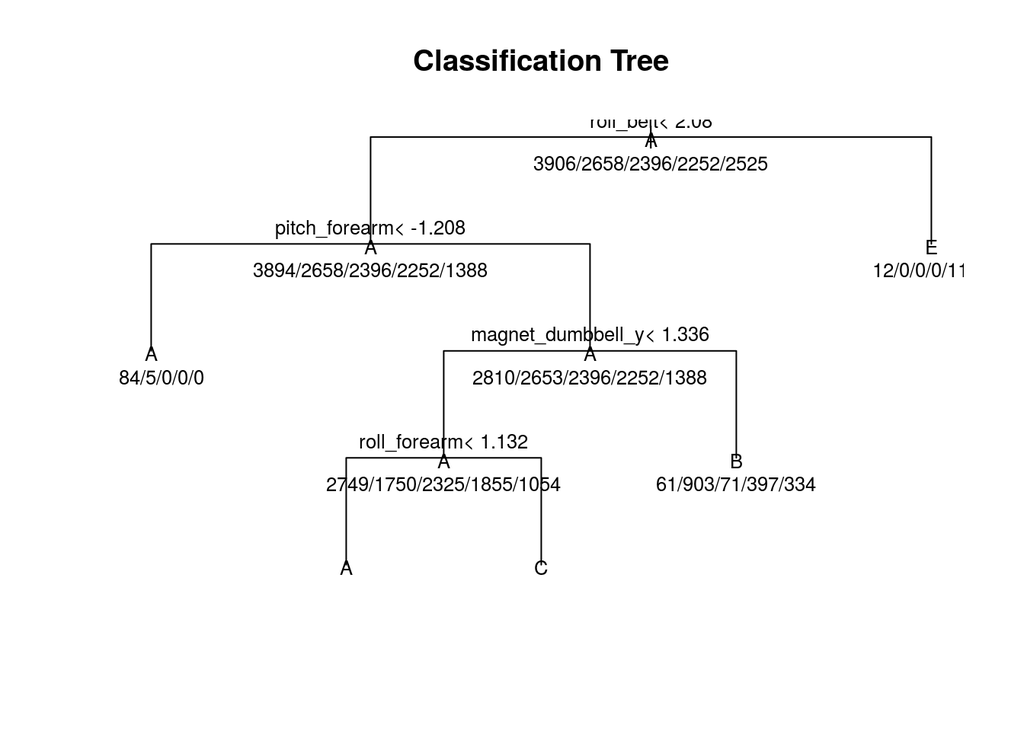

```r
plot(rpartFit$finalModel, uniform = TRUE, main = "Classification Tree")
text(rpartFit$finalModel, use.n = TRUE, all = TRUE, cex = .8)
```

Let’s then predict some new variables from the testing set and calculate the confusion matrix, in order to evaluate the accuracy of the model.

```r
predRpart <- predict(rpartFit, testing.new)

# prints the confusion matrix
confusionMatrix(predRpart, testing.new$classe)
```

```
## Confusion Matrix and Statistics
##
##           Reference
## Prediction    A    B    C    D    E
##          A 1523  478  486  423  160
##          B   20  383   37  171  152
##          C  129  278  503  370  276
##          D    0    0    0    0    0
##          E    2    0    0    0  494
##
## Overall Statistics
##
##                Accuracy : 0.4933
##                  95% CI : (0.4804, 0.5061)
##     No Information Rate : 0.2845
##     P-Value [Acc > NIR] : < 2.2e-16
##
##                   Kappa : 0.3376
##  Mcnemar's Test P-Value : NA
##
## Statistics by Class:
##
##                      Class: A Class: B Class: C Class: D Class: E
## Sensitivity            0.9098  0.33626  0.49025   0.0000  0.45656
## Specificity            0.6326  0.91993  0.78329   1.0000  0.99958
## Pos Pred Value         0.4961  0.50197  0.32326      NaN  0.99597
## Neg Pred Value         0.9464  0.85240  0.87919   0.8362  0.89089
## Prevalence             0.2845  0.19354  0.17434   0.1638  0.18386
## Detection Rate         0.2588  0.06508  0.08547   0.0000  0.08394
## Detection Prevalence   0.5217  0.12965  0.26440   0.0000  0.08428
## Balanced Accuracy      0.7712  0.62810  0.63677   0.5000  0.72807
```

I don’t have a good accuracy with this model, it is below 50%. So let’s try now with a random forest model, in order to try and increase the accuracy of the prediction capability.

```r
rfFit <- train(classe ~ ., method = "rf", data = training.new, model = FALSE, preProcess = "scale", trControl = fitControl, ntree = 5)
rfFit$finalModel
```

```
##
## Call:
##  randomForest(x = x, y = y, ntree = 5, mtry = param$mtry, model = FALSE)
##                Type of random forest: classification
##                      Number of trees: 5
## No. of variables tried at each split: 27
##
##         OOB estimate of  error rate: 5.77%
## Confusion matrix:
##      A    B    C    D    E class.error
## A 3380   55   17   18   14  0.02985075
## B   74 2174   53   36   30  0.08153781
## C   15   76 2006   38   13  0.06610801
## D   22   38   58 1896   24  0.06967615
## E   13   39   32   46 2152  0.05696757
```

## Out of sample error

Once modeled, let’s predict new values from the testing data frame and calculate the confusion matrix on the testing data frame to calculate the out of sample error.

```r
predRf <- predict(rfFit, testing.new)

# prints the confusion matrix
confusionMatrix(predRf, testing.new$classe)
```

```
## Confusion Matrix and Statistics
##
##           Reference
## Prediction    A    B    C    D    E
##          A 1666   18    1    0    0
##          B    5 1106   15    2    6
##          C    2   10 1001   17    8
##          D    1    2    8  941    5
##          E    0    3    1    4 1063
##
## Overall Statistics
##
##                Accuracy : 0.9816
##                  95% CI : (0.9779, 0.9849)
##     No Information Rate : 0.2845
##     P-Value [Acc > NIR] : < 2.2e-16
##
##                   Kappa : 0.9768
##  Mcnemar's Test P-Value : NA
##
## Statistics by Class:
##
##                      Class: A Class: B Class: C Class: D Class: E
## Sensitivity            0.9952   0.9710   0.9756   0.9761   0.9824
## Specificity            0.9955   0.9941   0.9924   0.9967   0.9983
## Pos Pred Value         0.9887   0.9753   0.9644   0.9833   0.9925
## Neg Pred Value         0.9981   0.9931   0.9948   0.9953   0.9961
## Prevalence             0.2845   0.1935   0.1743   0.1638   0.1839
## Detection Rate         0.2831   0.1879   0.1701   0.1599   0.1806
## Detection Prevalence   0.2863   0.1927   0.1764   0.1626   0.1820
## Balanced Accuracy      0.9954   0.9826   0.9840   0.9864   0.9904
```

We can see now that the accuracy is now equal to **98%**, that is a very good value for a predictive model.

Finally, let’s predict data for the initial testing data frame, that doesn’t have the **classe** variable. I join then the prediction to the testing data frame

```r
library(dplyr)
predRf <- predict(rfFit, testing) %>% data.frame()
names(predRf)[1] <- "pred_classe"
test.pred <- testing %>% bind_cols(predRf)
```

Let’s see now the predicted values for the **classe** value

```r
test.pred$pred_classe
```

```
##  [1] B A A A A E D B A A B C B A E E A B B B
## Levels: A B C D E
```